# **Proyecto: Analisis de expresion diferencial usando datos de RNAseq**

Ana Sofia Escobedo Muñoz

28/02/21

# **Procesos inflamatorios relacionados con la infeccion de M. tuberculosis: analisis de expresion diferencial**

La tuberculosis es una de las enfermedades infecciosas con el mayor numero de casos en el mundo, presentandose principalmente en paises en vias de desarrollo. Esto se acompaña con el hecho que casi un cuarto de la poblacion mundial tiene a Mycobacterium tuberculosis latente en su corrente sanguineo, pudiendo desarrollar el cuadro patologico completo, caracterizado por fiebre, perdida de peso, esputo sanguinolento y tos. En 2018, de los 10 millones de casos de tuberculosis activa 1.5 millones terminaron en fatalitades, posicionando a la TB como la enfemedad infecciosa mas mortifera al dia de hoy.

Uno de los efectos mas reconocibles de la TB es la inflamacion de los pulmones, provocada por la presencia de globulos blancos (neutrofilos, macrofagos, etc.) en las zonas circundantes. Dicha reaccion manifiesta altos niveles de citocinas, proteinas de fase aguda entre otros mediadores inflamatorios.

Analisis de perfilamiento transcriptomico en pacientes con TB activa demostraron elevaciones de la expresion genica en vias de inflamacion, influyendo la via del interferon (IFN), la del receptor complemento FC, entre otras.

A pesar de que la investigacion acerca de este padecimiento es bastante vieja, todavia no se ha caracterizado por completo las dinamicas inmunologicas desde la infeccion hasta el desarrollo de la sintomatologia.

Por eso mismo, se pretende hacer un analisis de expresion diferencial con datos de individuos con TB y sanos, tratando de observar patrones de expresion previamente caracterizados.

## *Descripcion biologica del set de datos*

El identificador SRP116272 corresponde a la investigacion *“Sequential inflammatory processes define human progression from M.tuberculosis infection to tuberculosis disease”* realizada por Thomas J. Scriba y compañia en 2017 (https://pubmed.ncbi.nlm.nih.gov/29145483/) donde se estudio el avance de la tuberculosis en jovenes de 12 a 18 años a nivel inmunologico usando el transcriptoma y proteoma de muestras tanto de sangre total como de plasma sanguineo.

Las 1650 muestras identificadas para este proyecto provenian de 44 adolescentes que desarrollaron tuberculosis en un lapso determinado de tiempo, y de 106 congeneres que se mantuvieron saludables durante 2 años. Igualmente incluyeron a 82 adultos a los que someterian a revacunacion, pero los datos de estos no se encuentran en el set en cuestion.

Fueron varios los analisis que hicieron incluyendo transcriptomica cinetica de sangre completa,observacion de marcadores proteicos solubles/proteomica de plasma, dinamica de grupos celulares en sangre periferica, seguimiento de respuesta mediada por TH17 en individuos revacunados y registro de celulas T.

La progresion de la tuberculosis fue asociada con la modulacion secuencial de procesos inmunologicos

La señalizacion del Interferon tipo I/II y relacionados fueron elevados 18 meses despues del diagnostico de tuberculosis, mientras cambios en la inflamacion mieloide, linfoide, neutrofilos y monocito cluster de genes ocurrieron cercanos a la enfermedad de la tuberculosis

Analisis de expresion genica en celulas T purificadas tambien revelaban supresion temprana de respuestas mediadas por TH17, comparadas con los controles

## *Procesado de datos*

Los datos fueron obtenidos y convertidos a un objetivo RSE con la ultima version de `recount3`. Posteriormente fue necesario la purificacion de muestras (SRRXXXXXX) cuyo apartado sra.sample_attribute estuviera vacio o con inconsistencias.

```r
# Crear objeto
human_projects <- available_projects()
proj_info <- subset(
    human_projects,
    project == "SRP116272" & project_type == "data_sources"
)
proj_SRP116272 <- create_rse(proj_info, verbose = FALSE)

# Añadir conteos al objeto RSE
assay(proj_SRP116272, "counts") <- compute_read_counts(proj_SRP116272)

# Quitar muestra con sra.sample_attributes vacio (de no quitarse el expand_sra_attributes() fallaria)
colDataRowMalita <- match('', proj_SRP116272$sra.sample_attributes)
proj_SRP116272 <- proj_SRP116272[,-colDataRowMalita]

# Expandir rubros en el colData y cambiar el tipo de variable de algunas columnas
proj_SRP116272 <- expand_sra_attributes(proj_SRP116272)
proj_SRP116272$sra_attribute.age <- as.numeric(proj_SRP116272$sra_attribute.age)
proj_SRP116272$sra_attribute.bin <- as.numeric(proj_SRP116272$sra_attribute.bin)
```

## *Revision de variables/atributos*

Tras la generacion del objeto, procedemos a analizar el comportamiento de rubros importantes dentro de `colData()` para cada muestra. De los 187 aspectos, se eligieron 6 provenientes de la expansion hecha con `expand_sra_attributes()`

```r
ggplotAttribute <- function(index){
    vecCat <- colData(proj_SRP116272)[,index]
    catName <- colnames(colData((proj_SRP116272)))[index]
    catCleanName <- str_replace(string=catName , pattern= 'sra_attribute.', replacement= '')
    preData <- data.frame(Categoria = vecCat)
    finalData <- transform(preData ,Categoria = factor(Categoria))
    ddFinalData <- ddply(finalData, .(Categoria), summarize, y=length(Categoria))
    plot <- ggplot(ddFinalData) +
        aes(x = Categoria, y=y , fill= Categoria) +
        geom_bar(position="dodge", stat="identity") +
        geom_text(aes(label=y), vjust=0, size= 2.5) +
        ggtitle(label= catCleanName) +
        theme(plot.title = element_text(size=12)) +
        theme(axis.title.x=element_blank(), axis.text.x=element_blank(), axis.ticks.x=element_blank())
    return(plot)
}

#Obtener los indices de las categorias deseadas
indexs <- match(c("sra_attribute.age", "sra_attribute.source_name", "sra_attribute.gender", "sra_attribute.stimulation", "sra_attribute.previousdiagnosisoftb", "sra_attribute.group"), colnames(colData(proj_SRP116272)))

#Crear plots
plotAge <- ggplotAttribute(indexs[1])
plotSource <- ggplotAttribute(indexs[2])
plotGender <- ggplotAttribute(indexs[3])
plotStimuli <- ggplotAttribute(indexs[4])
plotPrevDiagTB <- ggplotAttribute(indexs[5])
plotGroup <- ggplotAttribute(indexs[6])

#Crear figuras
figure1 <- ggarrange(plotSource, plotGender, plotPrevDiagTB, plotGroup, ncol = 2, nrow = 2)
figure2 <- ggarrange(plotAge, plotStimuli, ncol = 2, nrow = 1)
```

De acuerdo con el estudio, solo conservaron un porcentaje pequeño de los 6,363 participantes iniciales, y dentro del grupo selecto hubo sobrerepresentacion de mujeres, posiblemente por el muestreo realizado. El mayor numero de muestras provenientes de celulas T se puede explicar revisando la metodologia del estudio principal, donde hubo mayor enfasis en este tipo celular, aunque en una de las fases incluyen a varios tipos de globulos blancos. Los grupos de estudio (infectados y sanos) se encuentran representados en proporciones casi 1:1, con excepcion de la categoria “Not a PP case”, la cual no es descrita con claridad en el articulo principal. La categoriaa “Previous Diagnosis of TB” hace referencia casos de doble infeccion en los individuos, los cuales son escasos; la infrarepresentacion de este grupo puede que aminore los datos para casos de inmunidad por infeccion (no vacunacion).

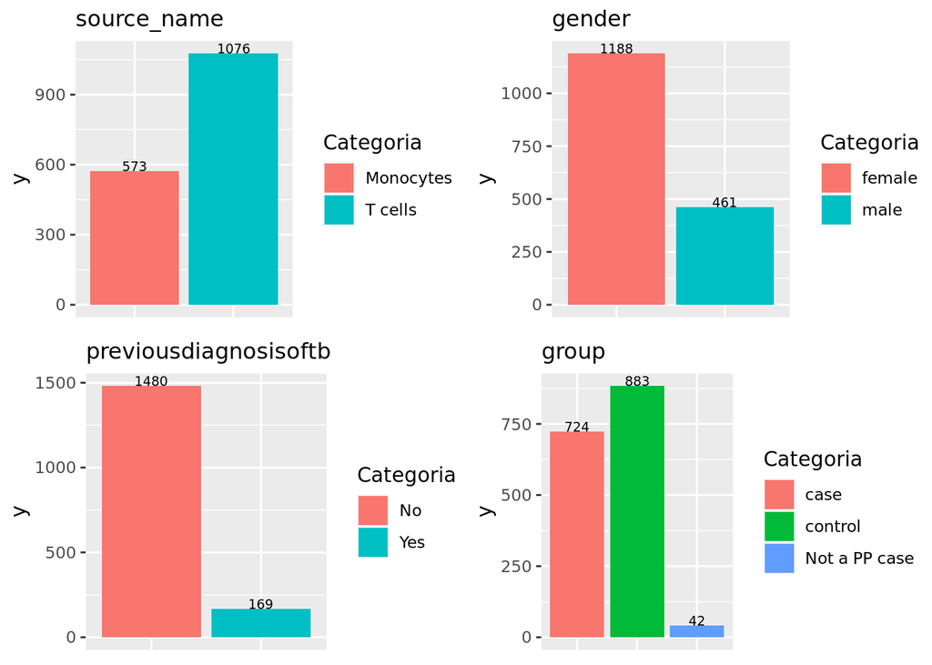

Por otro lado, el demografico de edad (12-18) tiene una mayor concentracion en individuos con 16 años. Cabe aclarar que las edades elegidas engloban una etapa vital muy variante, razon por la que los investigadores quizas no depositaron su interes, si no en los grupos controles. Para hacer la separacion de monocitos y celulas T fue necesario tener estimulos con antigenos *M.tb* y esto representaria la categoria stimulation.

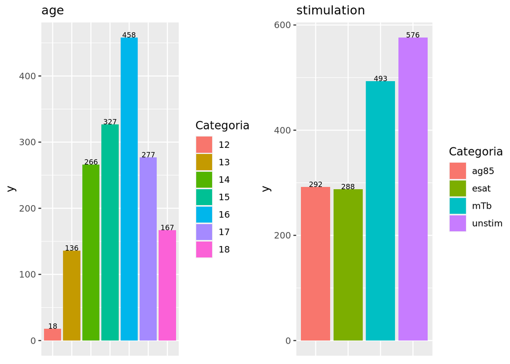

## *Purificacion*

### Analizando muestras

Se analizan categorias de recount para el conteo de expresion de genes (con analisis de lecturas)

```r
proj_SRP116272$assigned_gene_prop <- proj_SRP116272$recount_qc.gene_fc_count_all.assigned / proj_SRP116272$recount_qc.gene_fc_count_all.total
summaryToDf(summary(proj_SRP116272$assigned_gene_prop))
```

| Min. | 0.02 |
| --- | --- |
| 1st Qu. | 0.61 |
| Median | 0.68 |
| Mean | 0.66 |
| 3rd Qu. | 0.73 |
| Max. | 0.85 |

Luego se observa la distribucion de este parametro en todas las muestras (1649)

```r
assigGeneProp <- data.frame(Categoria = proj_SRP116272$assigned_gene_prop)
figure3 <-ggplot(assigGeneProp, aes(x=Categoria)) +
  geom_histogram(color="black", fill= 'darkred') +
  xlab('Assigned gene prop')
```

Afortunadamente, una gran parte de los datos se encuentra en un umbral aceptable de representacion. Con el objetivo de reducir ruido, se eliminaran los muestras cuya proporcion de genes es menor a 0.5

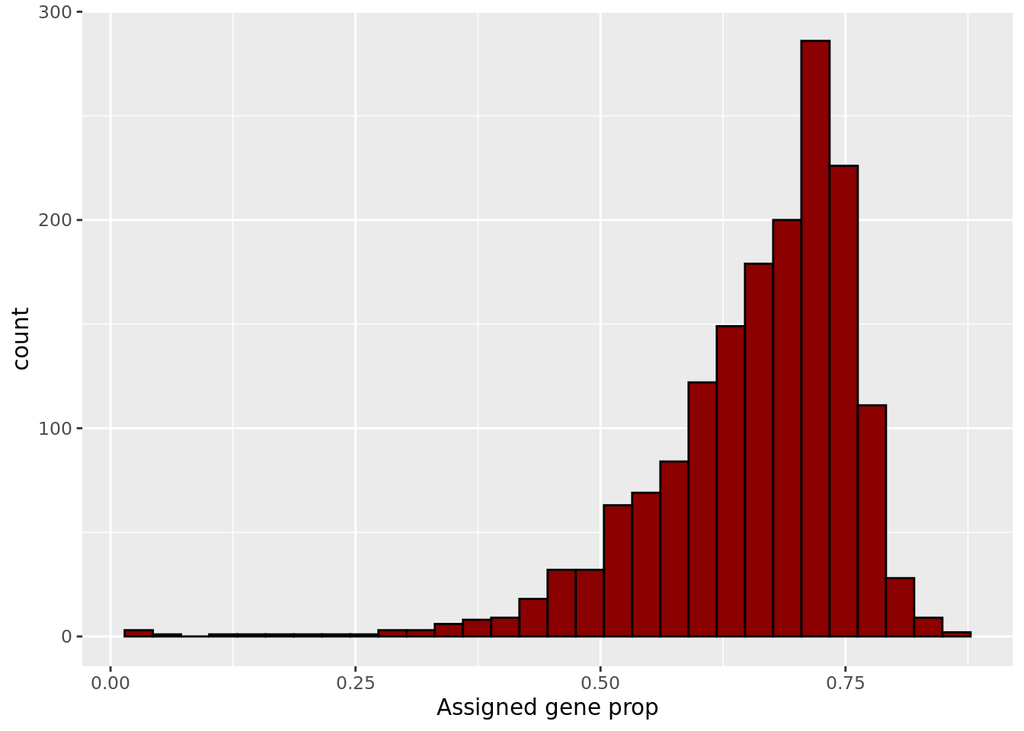

Dichas muestras representan un 7.09 % de las muestras totales (117 de 1649)

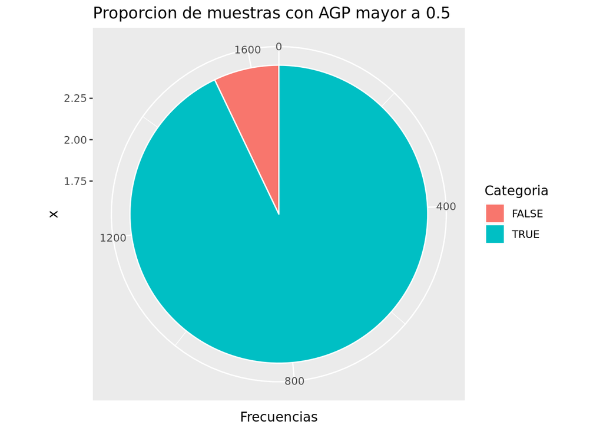

```r
agpDf <- as.data.frame(table(proj_SRP116272$assigned_gene_prop > 0.5))
ggPieDataAGP <- data.frame(Categoria = agpDf$Var1, Frecuencias = agpDf$Freq)
figure4 <- ggplot(ggPieDataAGP) +
    aes(x=2, y= Frecuencias, fill=Categoria) +
    geom_bar(stat = "identity", color = "white") +
    coord_polar(theta = "y", start=0) +
  ggtitle('Proporcion de muestras con AGP mayor a 0.5')
```

Se realiza la eliminacion de muestras con AGP (assigned gene prop) menor a 0.5

```r
#proj_SRP116272 <- proj_SRP116272_unfiltered
proj_SRP116272_unfiltered <- proj_SRP116272
proj_SRP116272 <- proj_SRP116272[, proj_SRP116272$assigned_gene_prop > 0.5]
```

### Analizando genes

Por el lado de los genes, se obtiene la media de las cuentas para cada uno de ellos

```r
gene_means <- rowMeans(assay(proj_SRP116272, "counts"))
summaryToDf(summary(gene_means))
```

| Min. | 0.00 |
| --- | --- |
| 1st Qu. | 0.01 |
| Median | 0.24 |
| Mean | 413.75 |
| 3rd Qu. | 20.23 |
| Max. | 1553955.95 |

```r
geMeanDf <- as.data.frame(table(gene_means>0.01))
ggPieDataGM <- data.frame(Categoria = geMeanDf$Var1, Frecuencias = geMeanDf$Freq)
figure5 <- ggplot(ggPieDataGM) +
    aes(x=2, y= Frecuencias, fill=Categoria) +
    geom_bar(stat = "identity", color = "white") +
    coord_polar(theta = "y", start=0) +
  ggtitle('Proporcion de genes con expresion promedio mayor a 0.01')
```

Haciendo uso de un principio similar que en la seccion pasada, se observa que casi un cuarto de los genes presentan un conteo promedio menor a 0.01, por lo que se deberán eliminar del analisis

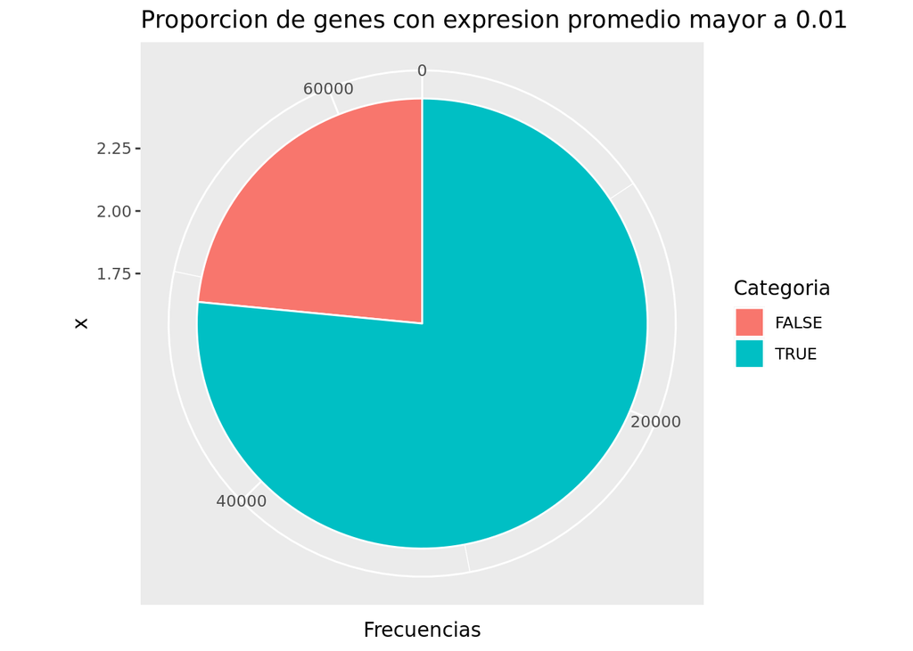

Se procede a hacer el ultimo filtrado, que nos conservará un 76.53 % del numero original de genes.

```r
proj_SRP116272 <- proj_SRP116272[gene_means > 0.01, ]
conservedGenesPer <- round(nrow(proj_SRP116272) / nrow(proj_SRP116272_unfiltered) * 100, 2)
message(paste('Porcentaje de genes conservados: ',conservedGenesPer))
```

```
Porcentaje de genes conservados:  76.53
```

## *Normalizacion*

```r
#Normalizacion de cuentas
dge <- DGEList(
    counts = assay(proj_SRP116272, "counts"),
    genes = rowData(proj_SRP116272)
)

dge <- calcNormFactors(dge)
```

## *Expresion diferencial*

### Analisis de relacion AGP con atributos de las muestras

Para la realizacion del modelo estadistico, es necesario revisar las relaciones que mantienen los atributos mas importantes de las muestras.

```r
#Funcion para hacer boxplots
boxPlottingAGP <- function(x, xlabel){
  boxPlot <- ggplot(as.data.frame(colData(proj_SRP116272)), aes(y = assigned_gene_prop, x = x, group=x )) +
    geom_boxplot() +
    theme_bw(base_size = 10) +
    ylab("Assigned Gene Prop") +
    xlab(xlabel)
}

boxPlotAgeAGP <- boxPlottingAGP(x = proj_SRP116272$sra_attribute.age, xlabel= "Age group")
boxPlotSourceAGP <- boxPlottingAGP(x = proj_SRP116272$sra_attribute.source_name, xlabel= "Source name")
boxPlotGenderAGP <- boxPlottingAGP(x = proj_SRP116272$sra_attribute.gender, xlabel= "Gender")
boxPlotGroupAGP <- boxPlottingAGP(x = proj_SRP116272$sra_attribute.group, xlabel= "Group")
boxPlotPreDiagAGP <- boxPlottingAGP(x = proj_SRP116272$sra_attribute.previousdiagnosisoftb, xlabel= "Previous diagnosis of TB")
boxPlotStimuliAGP <- boxPlottingAGP(x = proj_SRP116272$sra_attribute.stimulation, xlabel= "Stimulation")

figure6 <- ggarrange(boxPlotSourceAGP, boxPlotGenderAGP, boxPlotPreDiagAGP, boxPlotGroupAGP , ncol = 2, nrow = 2)
figure7 <- ggarrange(boxPlotAgeAGP, boxPlotStimuliAGP, ncol = 2, nrow = 1)
```

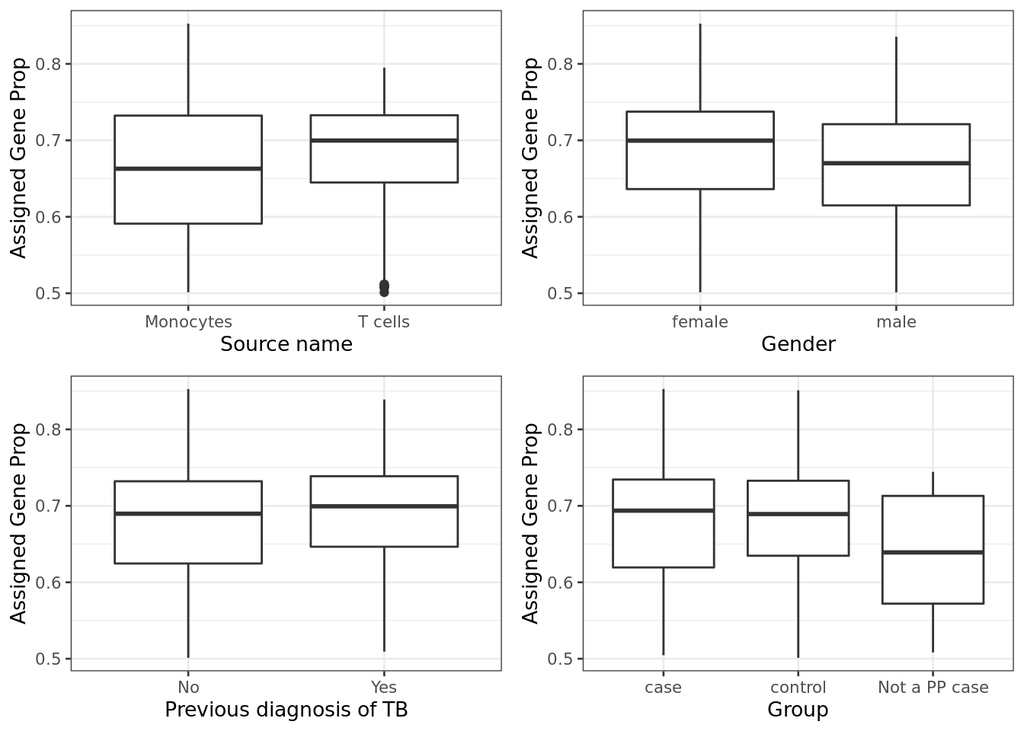

Un caso interesante es el de la edad, pues las proporciones vistas en la primera exploracion desaparecen, y aunque el grupo de 16 años esta sobrerepresantado su AGP es menor que el de 12 (con menos de una decima parte de representacion). Otra variable con posible relevancia estadistica seria el meotodo de estimulacion.

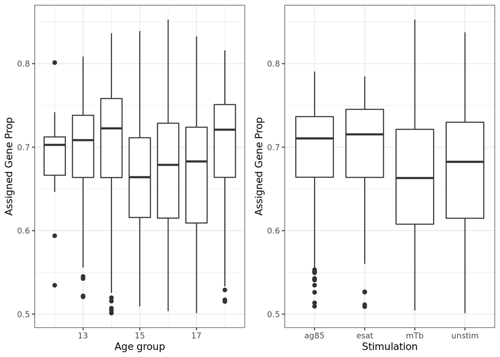

### Modelo estadistico

Con las variables anteriormente mencionadas, se realizará el modelo para la ED

```r
#Subset de colData() para la creacion del modelo
dataModelClean <- DataFrame(cbind(proj_SRP116272$sra_attribute.age, proj_SRP116272$sra_attribute.bin, proj_SRP116272$sra_attribute.source_name, proj_SRP116272$sra_attribute.gender, proj_SRP116272$sra_attribute.stimulation, proj_SRP116272$sra_attribute.previousdiagnosisoftb, proj_SRP116272$sra_attribute.group))
rownames(dataModelClean) <- colnames(proj_SRP116272)
colnames(dataModelClean) <- c('sra_attribute.age', 'sra_attribute.bin', 'sra_attribute.source_name', 'sra_attribute.gender', 'sra_attribute.stimulation', 'sra_attribute.previousdiagnosisoftb', 'sra_attribute.group')
dataModelClean$sra_attribute.age <- as.numeric(dataModelClean$sra_attribute.age)
dataModelClean$sra_attribute.bin <- as.numeric(dataModelClean$sra_attribute.bin)

#Crear modelo
mod <- model.matrix(~ sra_attribute.age + sra_attribute.source_name + sra_attribute.gender + sra_attribute.stimulation + sra_attribute.previousdiagnosisoftb + sra_attribute.group,
    data = dataModelClean)

#Observar colnames del modelo
colnames(mod)
```

```
 [1] "(Intercept)"
 [2] "sra_attribute.age"
 [3] "sra_attribute.source_nameT cells"
 [4] "sra_attribute.gendermale"
 [5] "sra_attribute.stimulationesat"
 [6] "sra_attribute.stimulationmTb"
 [7] "sra_attribute.stimulationunstim"
 [8] "sra_attribute.previousdiagnosisoftbYes"
 [9] "sra_attribute.groupcontrol"
[10] "sra_attribute.groupNot a PP case"
```

### Analisis ED

Se realiza un analisis inicial con el paquete `limma`

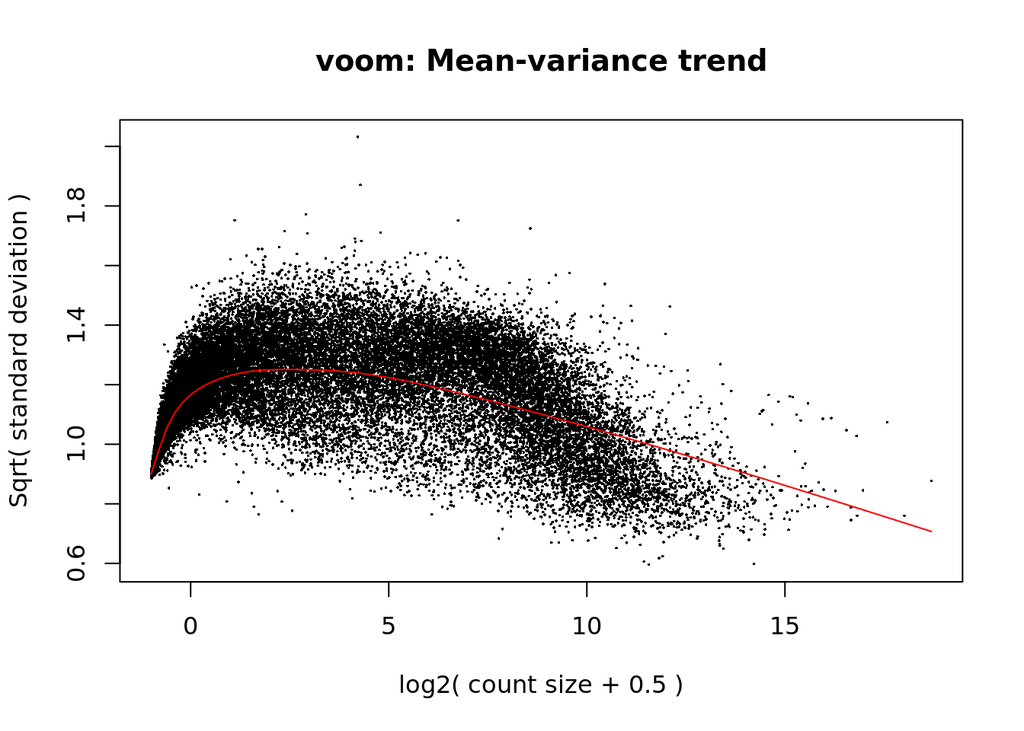

```r
vGene <- voom(dge, mod, plot = TRUE)
```

Se realiza con los datos obtenidos de limma un enfoque Bayesiano y la posterior creacion de los resultados de ED propiamente dichos

```r
eb_results <- eBayes(lmFit(vGene))

de_results <- topTable(
    eb_results,
    coef = 9,
    number = nrow(proj_SRP116272),
    sort.by = "none")
```

## *Analisis y contraste de resultados*

### Visualizacion de correlaciones con atributos

Se observa la proporcion de genes diferencialmente expresados

```r
table(de_results$adj.P.Val < 0.05)
```

```
FALSE  TRUE
45101  3768
```

Se realiza un ploteo con respecto a la categoria `source_name`

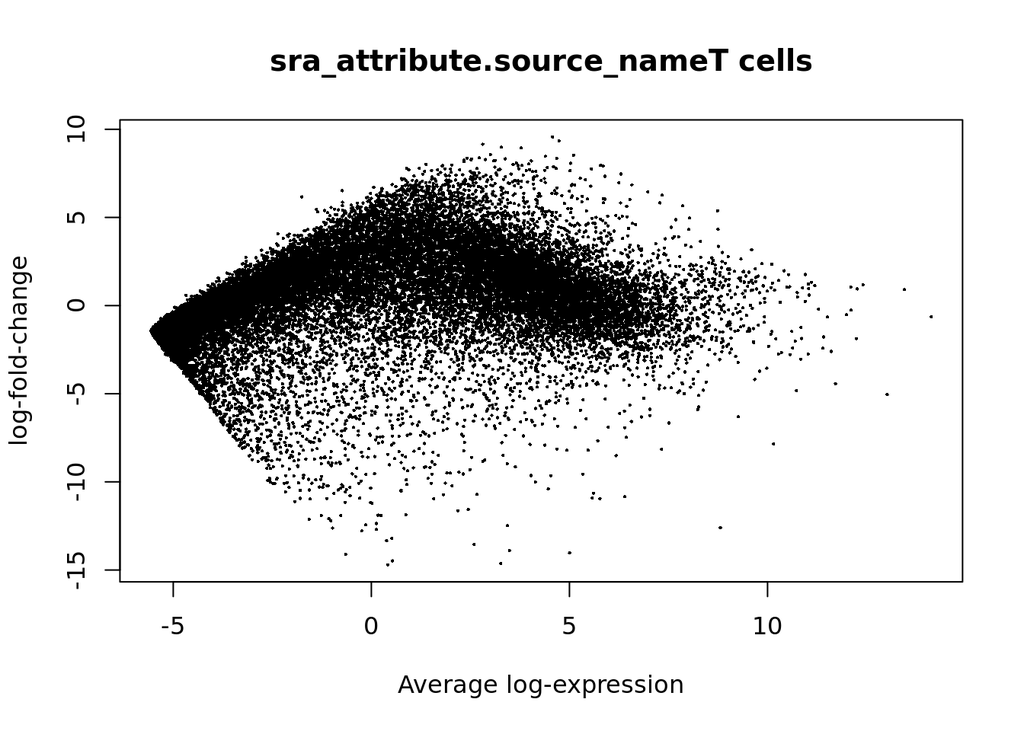

```r
plotMA(eb_results, coef = 3)
```

Despues con respecto a la categoria `group`

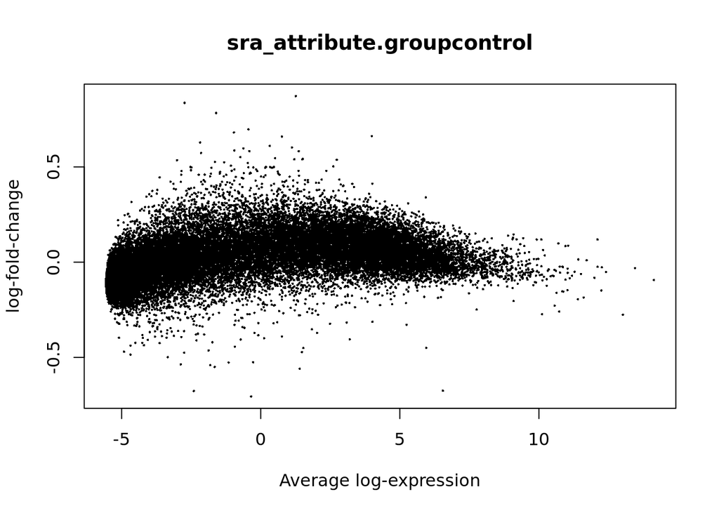

```r
plotMA(eb_results, coef = 9)
```

Finalmente con respecto a `(Intercept)`

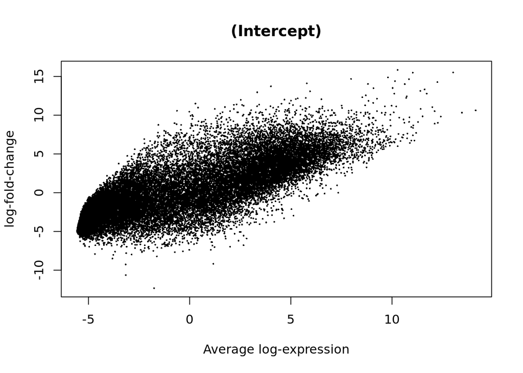

```r
plotMA(eb_results, coef = 1)
```

### Genes mas diferencialmente expresados y su contexto biologico

Con los datos anteriores y las variables analizadas, se puede obtener graficamente los genes mas dif. expresados.

Primero con respecto a `(Intercept)`

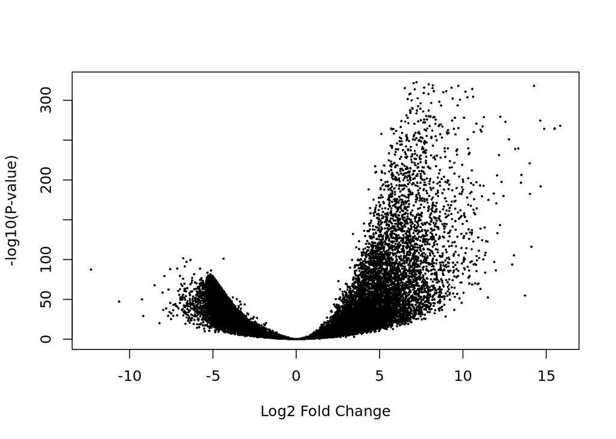

```r
volcanoplot(eb_results, coef = 1, highlight = 3, names = de_results$gene_name)
```

Luego con respecto a `group`

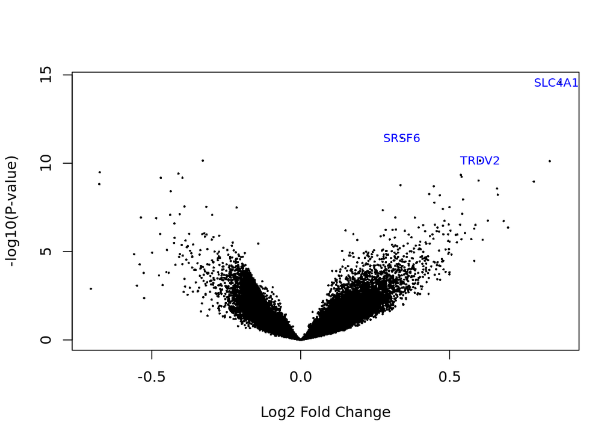

```r
volcanoplot(eb_results, coef = 9, highlight = 3, names = de_results$gene_name)
```

Despues con respecto a `source_type`

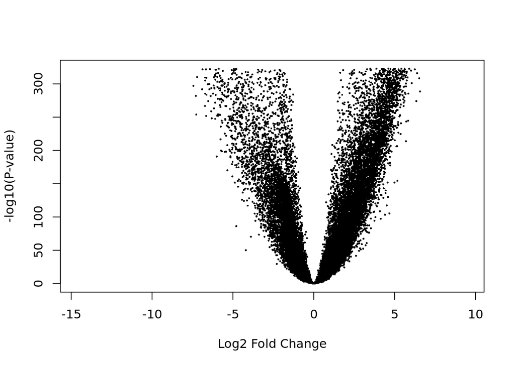

```r
volcanoplot(eb_results, coef = 3, highlight = 3, names = de_results$gene_name)
```

Y por ultimo con respecto a `age`

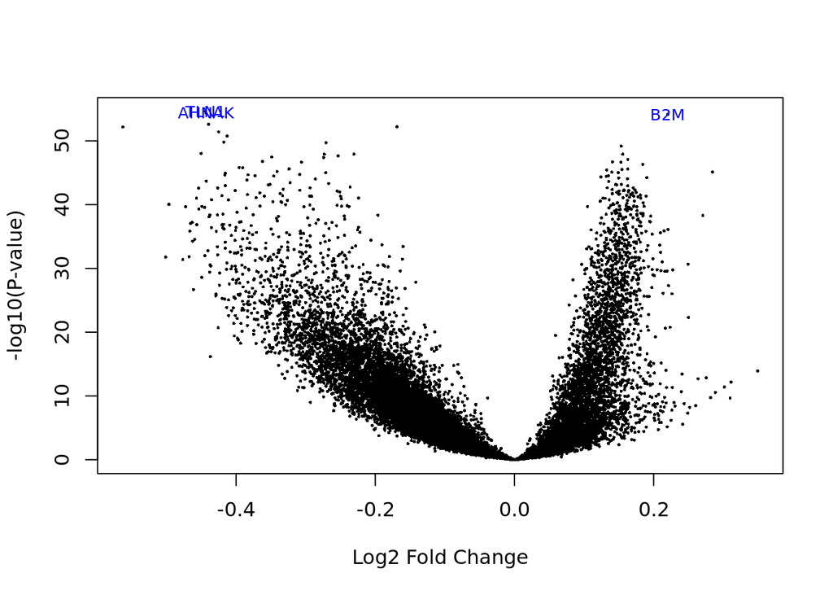

```r
volcanoplot(eb_results, coef = 2, highlight = 3, names = de_results$gene_name)
```

En total, los genes que podrian interesarnos son: B2M, AHNAK, TLN1, SCL4A1, SRSF6, TRDV2

Procederemos a selecionarlos de la matriz de ED

```r
de_results[de_results$gene_name %in% c("B2M", "AHNAK", "TLN1", "SLC4A1", "SRSF6", "TRDV2"), ]
```

[output not shown]

Para todos los genes se realizó una busqueda en GeneCards, y las descripciones se encuentran a continuacion:

| Genes | Descripciones |
| --- | --- |
| B2M | Este gen codifica una proteína sérica que se encuentra en asociación con la cadena pesada de clase I del complejo principal de histocompatibilidad (MHC) en la superficie de casi todas las células nucl… |
| AHNAK | La proteína codificada por este gen es una proteína de estructura estructural grande (700 kDa) que consta de un dominio central con repeticiones de 128 aa. La proteína codificada puede desempeñar un p… |
| TLN1 | Este gen codifica una proteína citoesquelética que se concentra en áreas de contacto célula-sustrato y célula-célula. La proteína codificada juega un papel importante en el ensamblaje de filamentos de… |
| SLC4A1 | La proteína codificada por este gen es parte de la familia de los intercambiadores de aniones (AE) y se expresa en la membrana plasmática de eritrocitos, donde funciona como un intercambiador de cloru… |
| SRSF6 | La proteína codificada por este gen está involucrada en el corte y empalme del ARNm y puede desempeñar un papel en la determinación del corte y empalme alternativo. La proteína nuclear codificada pert… |
| TRDV2 | Los receptores de células T reconocen antígenos extraños que se han procesado como péptidos pequeños y se han unido a moléculas del complejo mayor de histocompatibilidad (MHC) en la superficie de las … |

### Visualizacion general de genes

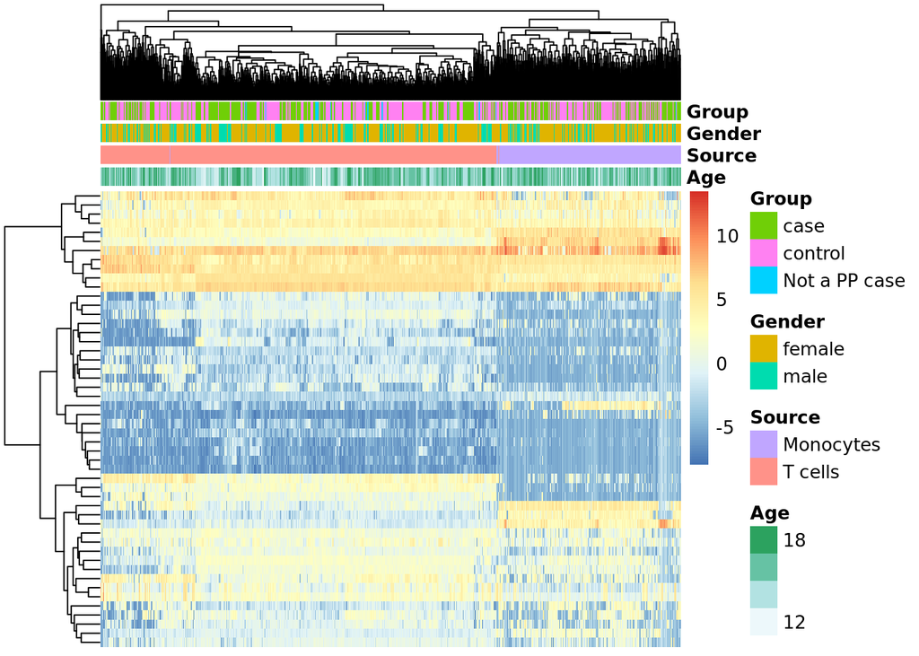

```r
exprs_heatmap <- vGene$E[rank(de_results$adj.P.Val) <= 50, ]

colDf <- colnames(dataModelClean)[-match(c("sra_attribute.bin", "sra_attribute.stimulation", "sra_attribute.previousdiagnosisoftb"), colnames(dataModelClean))]
df <- as.data.frame(colData(proj_SRP116272)[, colDf])
colnames(df) <- c("Age", "Source", "Gender",  "Group")

pheatmap(
    exprs_heatmap,
    cluster_rows = TRUE,
    cluster_cols = TRUE,
    show_rownames = FALSE,
    show_colnames = FALSE,
    annotation_col = df)
```

## *Conclusiones*

Los patrones de expresion diferencial detectados en este trabajo no definen de manera absoluta aquellas distribuciones encontradas en el paper principal, sobre todo por el enfoque tan distinto en el que se hizo el estudio. Sin embargo, aquellos genes que destacaron por sus valores de expresion muchas veces caian de categorias relacionadas con procesos inflamatorios, confirmando la premisa que la infeccion de M. tuberculosis tiene un efecto inmenso en los procesos inmunoinflamatorios, sobre todo registrados por celulas T. En un futuro, de continuarse este proyecto, se trataria de refinar el analisis, y usar datos de expresion de otros estudios relacionados, para así encontrar patrones en distintas fases de la infeccion, procurando una representacion equitativa entre todoas las categorias para reducir en la medida de lo posible el sesgo.